# Árvores de Classificação e Aplicações

## Árvore de Decisão

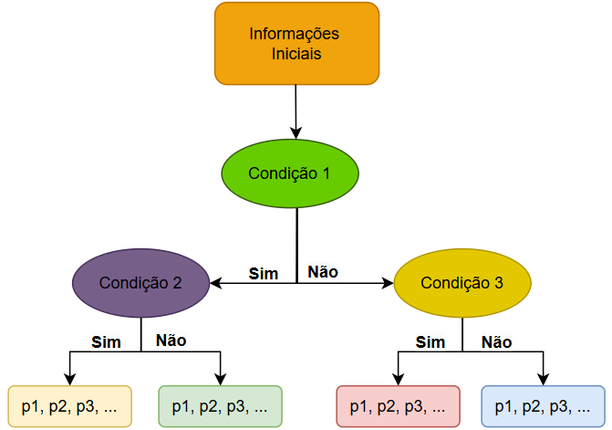

**Figura 1:** Árvore de Decisão.

## Entropia

Quantidade capaz de caracterizar o grau de desordem de um sistema. Desse modo, valores altos de entropia refletem a desorganização do conjunto em estudo enquanto valores baixos indicam uma maior organização. Na literatura, é dada por:

\(Entropia = - \sum p_i \cdot log_2 p_i\)

em que \(p_i\) é a probabilidade do evento \(i\) ocorrer.

## Entropia

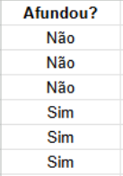

**Tabela 1:** Entropia no Banco de Dados.

## Entropia

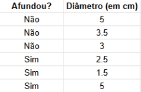

**Tabela 2:** Entropia no Banco de Dados.

## Entropia

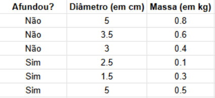

**Tabela 3:** Entropia no Banco de Dados.

## Entropia

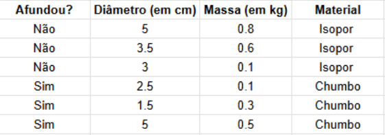

**Tabela 4:** Entropia no Banco de Dados.

## Ganho de Informação

Caracteriza a redução de incertezas de um sistema ocasionada pela partição em determinado atributo. Na literatura:

\[ \small Ganho\_info(S,A) = Entropia(S) - \sum \limits_{v \in Values(A)} \frac{|S_v|}{|S|} \cdot Entropia(S_v) \]

em que Entropia(S) representa o valor da entropia no conjunto inicial, \(Values(A)\) são os valores possíveis para \(A\), \(v\) um elemento pertencente a esse conjunto e \(S_{V}\) um subconjunto de \(S\) tal que \(A(s) = v\).

## Ganho de Informação

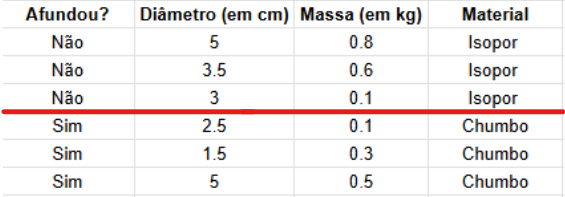

**Tabela 5:** Ganho de Informação no Banco de Dados.

## Lógica para Programação

- **Otimizar**: Recebe a coluna resposta e a coluna em que será feito o corte identificando em qual local o corte deve ser feito para trazer maior ganho de informação.
- **Avaliar**: Recebe o banco de dados e identifica em qual variável o corte deve ser realizado.
- **Subtabela**: Mecanismo capaz de dividir o banco de dados em duas partes.
- **Construir ramos filhos**: Mecanismo recursivo capaz de realizar diversos cortes na árvore usando o subtabela, por meio dele o usuário pode determinar a profundidade máxima dos ramos e o ganho de informação mínimo para o corte.
- **Classificar**: Classificar novas informações com base na árvore construída.

## Esquema

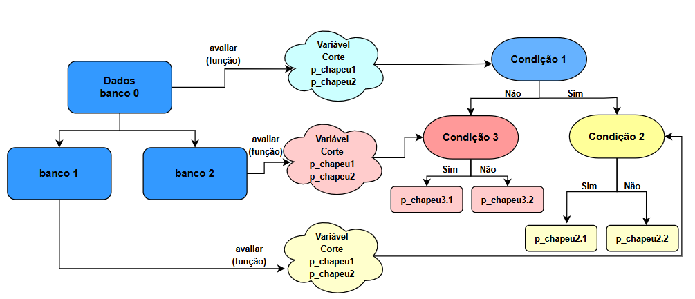

**Figura 2:** Funções aplicadas para a construção da árvore.

## Métricas de Avaliação

- **Matriz de confusão**: Tabela que compara os valores previstos com os valores reais.

|  | Verdadeiro Observado | Falso Observado |
| --- | --- | --- |
| Positivo Previsto | VP | FN |
| Negativo Previsto | FP | VN |

- **Acurácia**: Relação entre o total de classificações feitas e as classificações feitas corretamente.

  \(Acurácia =\frac{VP+VN}{VP+VN+FP+FN}\)

## Métricas de Avaliação

  \(Precisão = \frac{VP}{VP+FP}\)
- Observação: A tabela perde a ideia de falso negativo, falso positivo, verdadeiro negativo e verdadeiro positivo no caso de mais de 2 categorias.

## Exemplo - Espécies de Planta

```r
iris[c(1,52,108,25,146),]
```

```
##     Sepal.Length Sepal.Width Petal.Length Petal.Width    Species
## 1            5.1         3.5          1.4         0.2     setosa
## 52           6.4         3.2          4.5         1.5 versicolor
## 108          7.3         2.9          6.3         1.8  virginica
## 25           4.8         3.4          1.9         0.2     setosa
## 146          6.7         3.0          5.2         2.3  virginica
```

```r
classificar(dados = iris[-c(1,52,108,25,146),],
            coluna_resposta = "Species",
            novas_informacoes = iris[c(1,52,108,25,146),1:4],
            g_info_min = 0.6, profundidade_max = 3)
```

```
## [1] "setosa"     "versicolor" "virginica"  "setosa"     "virginica"
```

## Exemplo - Espécies de Planta

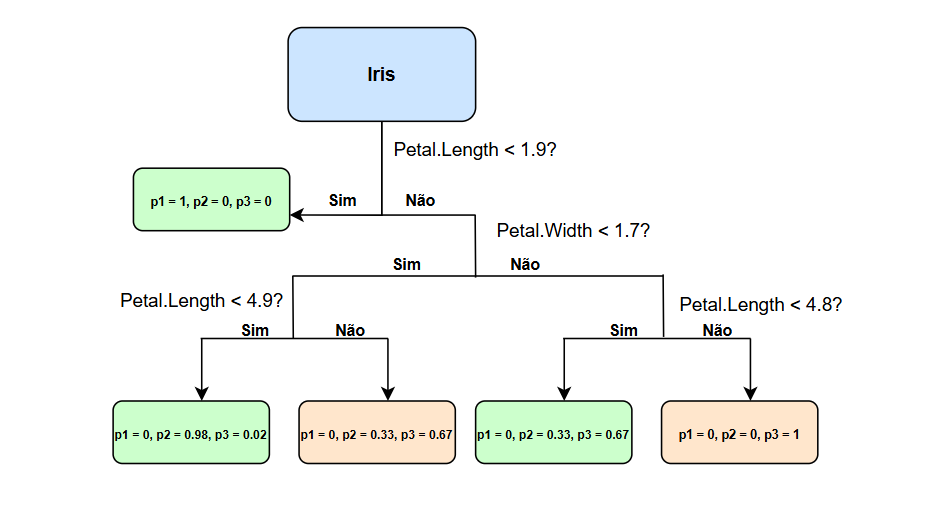

**Figura 3:** Árvore de Classificação do Banco de Dados Iris.

## Exemplo - Aprovação de Crédito

```r
head(Default)
```

```
##   default student   balance    income
## 1      No       0  729.5265 44361.625
## 2      No       1  817.1804 12106.135
## 3      No       0 1073.5492 31767.139
## 4      No       0  529.2506 35704.494
## 5      No       0  785.6559 38463.496
## 6      No       1  919.5885  7491.559
```

## Hold-Out - Aprovação de Crédito

```r
resultados <- avaliar_arvore_Hold_Out(Default, "default",
                                      n_linhas_treino = 9000,
                                      profundidade_max = 3,
                                      g_info_min = 0.025)
```

```r
resultados$matriz_confusao
```

```
##        verdadeiro
## predito  No Yes
##     No  963  21
##     Yes   6  10
```

## Hold-Out - Aprovação de Crédito

```r
resultados$acuracia
```

```
## [1] 0.973
```

```r
resultados$recall
```

```
##        No       Yes
## 0.9938080 0.3225806
```

```r
resultados$precisao
```

```
## [1] 0.9786585 0.6250000
```

## K-Fold - Aprovação de Crédito

```r
resultado <- avaliar_arvore_K_fold(data = Default,
                                   coluna_resposta = "default",
                                   g_info_min = 0.05)
```

```r
resultado$acuracia
```

```
## [1] 0.9667
```

```r
resultado$recall
```

```
## [1] 0.5
```

```r
resultado$precisao
```

```
## [1] 0.9667
```

## Conclusão

As árvores de decisão são mecanismos que fornecem critérios simples de classificação e extremamente poderosas para a realização de predições de grupos.  
O pacote desenvolvido pode ser acessado por meio do link:

[figure not shown]

## Referências

- Mitchell, Thomas M. Machine Learning. New York, Mcgraw-Hill, 1997.
- Didática Tech. “Árvore de Decisão - Como Funciona (Machine Learning).” Disponível em: www.youtube.com/watch?v=W7MfsE5av0c.
- Classificação: precisão, recall, precisão e métricas relacionadas. Disponível em: developers.google.com/machine-learning/crash-course/classification.

## Agradecimentos

Agradeço ao meu orientador Victor Freguglia Souza, ao coordenador do PICME Giuliano Angelo Zugliani, à agência de fomento à pesquisa CNPq e aos amigos e familiares pelo apoio durante o desenvolvimento deste projeto.